# Practical Machine Learning Course Project

Carl Huelgas

14 Januar 2017

## Required packages

```r
library(caret)
```

```r
library(ggplot2)
```

# Abstract

The goal of the assignment is to predict the way in which a fitness excercise is performed. The given data contains 19622 observations over 160 variables. Therefore the data contains 159 predictors and one variable to predict (classe). As a goal an out of sample error of over 0.8 is aimed.

The data was preprocessed and the random forest algorithm was used to predict the outcome of the excercise. The actual out of sample accuracy of the prediction is approx. 0.9957.

## Loading the Data and Partitioning

In a first step the given data is loaded and a training and test dataset is created using the function createDataPartition with p=0.6. The value was choosen because of the large dataset.

```r
pml.training <- read.csv("~/Documents/Data Science/Practical Machine Learning/pml-training.csv")
train <- pml.training
set.seed(123)
inTrain <- createDataPartition(y=train$classe, p=0.6, list=FALSE)
train.train <- train[inTrain,]
train.test <- train[-inTrain,]
```

## First analysis of the data

```r
str(train.train[,1:10])
```

```
## 'data.frame':    11776 obs. of  10 variables:
##  $ X                   : int  3 4 6 10 11 12 13 17 18 19 ...
##  $ user_name           : Factor w/ 6 levels "adelmo","carlitos",..: 2 2 2 2 2 2 2 2 2 2 ...
##  $ raw_timestamp_part_1: int  1323084231 1323084232 1323084232 1323084232 1323084232 1323084232 1323084232 1323084232 1323084232 1323084232 ...
##  $ raw_timestamp_part_2: int  820366 120339 304277 484434 500302 528316 560359 692324 732306 740353 ...
##  $ cvtd_timestamp      : Factor w/ 20 levels "02/12/2011 13:32",..: 9 9 9 9 9 9 9 9 9 9 ...
##  $ new_window          : Factor w/ 2 levels "no","yes": 1 1 1 1 1 1 1 1 1 1 ...
##  $ num_window          : int  11 12 12 12 12 12 12 12 12 12 ...
##  $ roll_belt           : num  1.42 1.48 1.45 1.45 1.45 1.43 1.42 1.51 1.55 1.57 ...
##  $ pitch_belt          : num  8.07 8.05 8.06 8.17 8.18 8.18 8.2 8.12 8.08 8.06 ...
##  $ yaw_belt            : num  -94.4 -94.4 -94.4 -94.4 -94.4 -94.4 -94.4 -94.4 -94.4 -94.4 ...
```

```r
summary(train.train[,1:10])
```

```
##        X            user_name    raw_timestamp_part_1 raw_timestamp_part_2
##  Min.   :    3   adelmo  :2338   Min.   :1.322e+09    Min.   :   294
##  1st Qu.: 4918   carlitos:1845   1st Qu.:1.323e+09    1st Qu.:252302
##  Median : 9808   charles :2154   Median :1.323e+09    Median :500338
##  Mean   : 9818   eurico  :1851   Mean   :1.323e+09    Mean   :501662
##  3rd Qu.:14732   jeremy  :2047   3rd Qu.:1.323e+09    3rd Qu.:756297
##  Max.   :19622   pedro   :1541   Max.   :1.323e+09    Max.   :998801
##
##           cvtd_timestamp new_window    num_window      roll_belt
##  28/11/2011 14:14: 892   no :11528   Min.   :  1.0   Min.   :-28.90
##  05/12/2011 11:24: 886   yes:  248   1st Qu.:223.0   1st Qu.:  1.10
##  30/11/2011 17:11: 870               Median :425.0   Median :113.00
##  02/12/2011 14:58: 853               Mean   :432.5   Mean   : 64.54
##  05/12/2011 11:25: 843               3rd Qu.:650.0   3rd Qu.:123.00
##  02/12/2011 14:57: 825               Max.   :864.0   Max.   :162.00
##  (Other)         :6607
##    pitch_belt          yaw_belt
##  Min.   :-55.8000   Min.   :-179.00
##  1st Qu.:  1.8000   1st Qu.: -88.30
##  Median :  5.2800   Median : -13.20
##  Mean   :  0.2876   Mean   : -11.25
##  3rd Qu.: 15.1000   3rd Qu.:  12.72
##  Max.   : 60.3000   Max.   : 179.00
##
```

Viewing the structure and the summary of the data (in the report only an example is shown) shows that there are numerous variables containing NA and factor variables with more the 30 levels. There are also some variables which are not relevant for prediction. The outcome is predicted by the variable classe with five levels (“A” to “E”).

## Preprocession of the data

In a first step the variables 1 to 5 are removed from the dataset. This is done because this variables will have no impact on the outcome (1 = index, 2 = name, 3 to 5 = timestamps).

```r
train.train.1 <- train.train[,-c(1:5)]
```

## Analyse/preprocess the factor variables - convert to numerical

A closer look at the factor variables (excluding classe) shows, that they actually should be numeric (e.g. skewness_pitch_dumbbell).

```r
train.train.2 <- data.frame(lapply(train.train.1[,-155],
                                   function(x) as.numeric(as.character(x))))
train.train.2$classe <- train.train.1$classe
```

## Analyse variables for near zero Variance

Next the variables are analysed for variance. Variables with near zero variance will be dropped from the further analysis.

```r
nzv <- nearZeroVar(train.train.2, saveMetrics=TRUE)
head(nzv[nzv$nzv,],10)
```

```
##                    freqRatio percentUnique zeroVar  nzv
## new_window                 0   0.000000000    TRUE TRUE
## kurtosis_yaw_belt          0   0.000000000    TRUE TRUE
## skewness_yaw_belt          0   0.000000000    TRUE TRUE
## amplitude_yaw_belt         0   0.008491848    TRUE TRUE
## avg_roll_arm              51   1.681385870   FALSE TRUE
## stddev_roll_arm           51   1.681385870   FALSE TRUE
## var_roll_arm              51   1.681385870   FALSE TRUE
## avg_pitch_arm             51   1.681385870   FALSE TRUE
## stddev_pitch_arm          51   1.681385870   FALSE TRUE
## var_pitch_arm             51   1.681385870   FALSE TRUE
```

```r
nzv_d <- nearZeroVar(train.train.2)
length(nzv_d)
```

```
## [1] 29
```

```r
train.train.3 <- train.train.2[,-nzv_d]
```

```r
preObj.1 <- preProcess(train.train.3, method="knnImpute", k=5)
train.train.4 <- predict(preObj.1, newdata = train.train.3)
```

# Model creation

As an algorithm for model creation “random forest” was choosen. To ensure that the model will not be overfitted a repeated cross validation with kfold = 5 and 2 repeats was passed to the algorithm by the trainControl argument.

In a first step the model was build using the standard settings von ntree=500.

```r
train_control <- trainControl(method="repeatedcv", number=5, repeats=2)
modFit.i <- train(classe ~ ., trControl=train_control, method="rf", data=train.train.4)
modFit.i$finalModel
```

```
##
## Call:
##  randomForest(x = x, y = y, mtry = param$mtry)
##                Type of random forest: classification
##                      Number of trees: 500
## No. of variables tried at each split: 63
##
##         OOB estimate of  error rate: 0.42%
## Confusion matrix:
##      A    B    C    D    E class.error
## A 3344    2    0    0    2 0.001194743
## B    6 2271    2    0    0 0.003510312
## C    0   10 2041    3    0 0.006329114
## D    0    0   16 1913    1 0.008808290
## E    0    1    0    6 2158 0.003233256
```

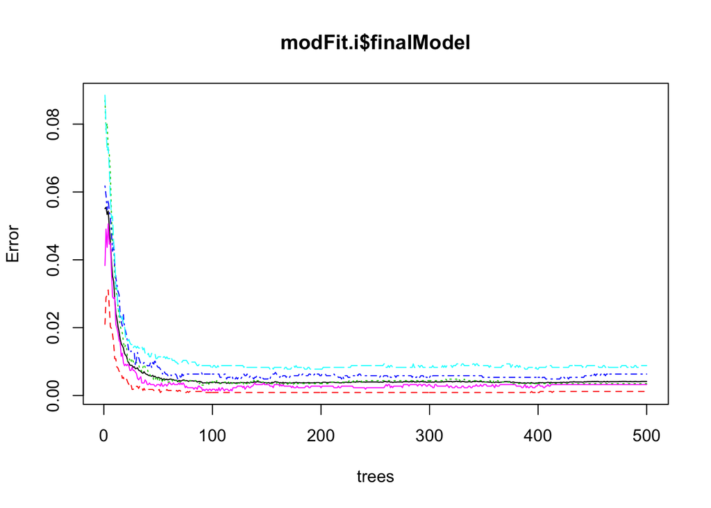

```r
plot(modFit.i$finalModel)
```

The out of the box error (OOB) of this first model is 0.42%.  
As can be seen by the plot the high number of trees does not improve the model accuracy. The time to calculate the model is also very high (due to the large amount of trees).  
In a second approach the number of trees (ntree) was set to 50 to improve performance without sacrificing accuracy.

```r
train_control <- trainControl(method="repeatedcv", number=5, repeats=2)
modFit1 <- train(classe ~ ., trControl=train_control, method="rf", ntree=50,
                 data=train.train.4)
modFit1$finalModel
```

```
##
## Call:
##  randomForest(x = x, y = y, ntree = 50, mtry = param$mtry)
##                Type of random forest: classification
##                      Number of trees: 50
## No. of variables tried at each split: 63
##
##         OOB estimate of  error rate: 0.47%
## Confusion matrix:
##      A    B    C    D    E class.error
## A 3344    2    0    0    2 0.001194743
## B    8 2268    2    1    0 0.004826678
## C    0    7 2043    4    0 0.005355404
## D    0    0   19 1910    1 0.010362694
## E    0    2    0    7 2156 0.004157044
```

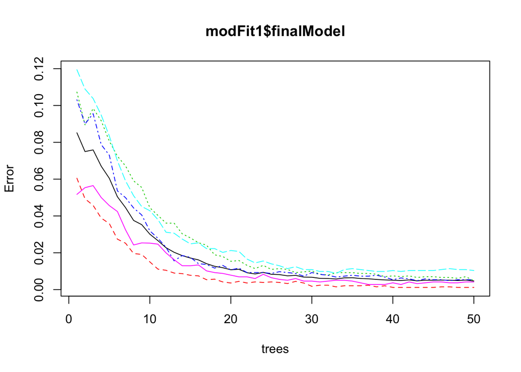

```r
plot(modFit1$finalModel)
```

The model statistics show an out of the box error (OOB) of 0.47% and therefore only slightly higher than in the first model. The confusion matrix support this very low error rate. As can be seen by the plot the number of trees (50) is more than sufficient to minimize the error rate.  
Analyse the model performance with the train data

```r
predictM1.train <- predict(modFit1, newdata = train.train.4[,-126])
confusionMatrix(predictM1.train, train.train.4[,126])
```

```
## Confusion Matrix and Statistics
##
##           Reference
## Prediction    A    B    C    D    E
##          A 3348    0    0    0    0
##          B    0 2279    0    0    0
##          C    0    0 2054    0    0
##          D    0    0    0 1930    0
##          E    0    0    0    0 2165
##
## Overall Statistics
##
##                Accuracy : 1
##                  95% CI : (0.9997, 1)
##     No Information Rate : 0.2843
##     P-Value [Acc > NIR] : < 2.2e-16
##
##                   Kappa : 1
##  Mcnemar's Test P-Value : NA
##
## Statistics by Class:
##
##                      Class: A Class: B Class: C Class: D Class: E
## Sensitivity            1.0000   1.0000   1.0000   1.0000   1.0000
## Specificity            1.0000   1.0000   1.0000   1.0000   1.0000
## Pos Pred Value         1.0000   1.0000   1.0000   1.0000   1.0000
## Neg Pred Value         1.0000   1.0000   1.0000   1.0000   1.0000
## Prevalence             0.2843   0.1935   0.1744   0.1639   0.1838
## Detection Rate         0.2843   0.1935   0.1744   0.1639   0.1838
## Detection Prevalence   0.2843   0.1935   0.1744   0.1639   0.1838
## Balanced Accuracy      1.0000   1.0000   1.0000   1.0000   1.0000
```

And with the test data (testing partition of the original train data). All preprocessing steps are first applied to the train.test data.

```r
train.test.1 <- train.test[,-c(1:5)]
train.test.2 <- data.frame(lapply(train.test.1[,-155],
                                  function(x) as.numeric(as.character(x))))
train.test.2$classe <- train.test.1$classe
train.test.3 <- train.test.2[,-nzv_d]
train.test.4 <- predict(preObj.1, newdata = train.test.3)

predictM1.test <- predict(modFit1, newdata=train.test.4[,-126])
confusionMatrix(predictM1.test, train.test.4[,126])
```

```
## Confusion Matrix and Statistics
##
##           Reference
## Prediction    A    B    C    D    E
##          A 2232    2    0    0    0
##          B    0 1513    7    0    0
##          C    0    2 1359   17    0
##          D    0    1    2 1269    3
##          E    0    0    0    0 1439
##
## Overall Statistics
##
##                Accuracy : 0.9957
##                  95% CI : (0.9939, 0.997)
##     No Information Rate : 0.2845
##     P-Value [Acc > NIR] : < 2.2e-16
##
##                   Kappa : 0.9945
##  Mcnemar's Test P-Value : NA
##
## Statistics by Class:
##
##                      Class: A Class: B Class: C Class: D Class: E
## Sensitivity            1.0000   0.9967   0.9934   0.9868   0.9979
## Specificity            0.9996   0.9989   0.9971   0.9991   1.0000
## Pos Pred Value         0.9991   0.9954   0.9862   0.9953   1.0000
## Neg Pred Value         1.0000   0.9992   0.9986   0.9974   0.9995
## Prevalence             0.2845   0.1935   0.1744   0.1639   0.1838
## Detection Rate         0.2845   0.1928   0.1732   0.1617   0.1834
## Detection Prevalence   0.2847   0.1937   0.1756   0.1625   0.1834
## Balanced Accuracy      0.9998   0.9978   0.9952   0.9929   0.9990
```

The confusion Matrix shows an out of sample accuracy of 0.9957 which is near perfect. The 20 most important variables are shown in the following plot:

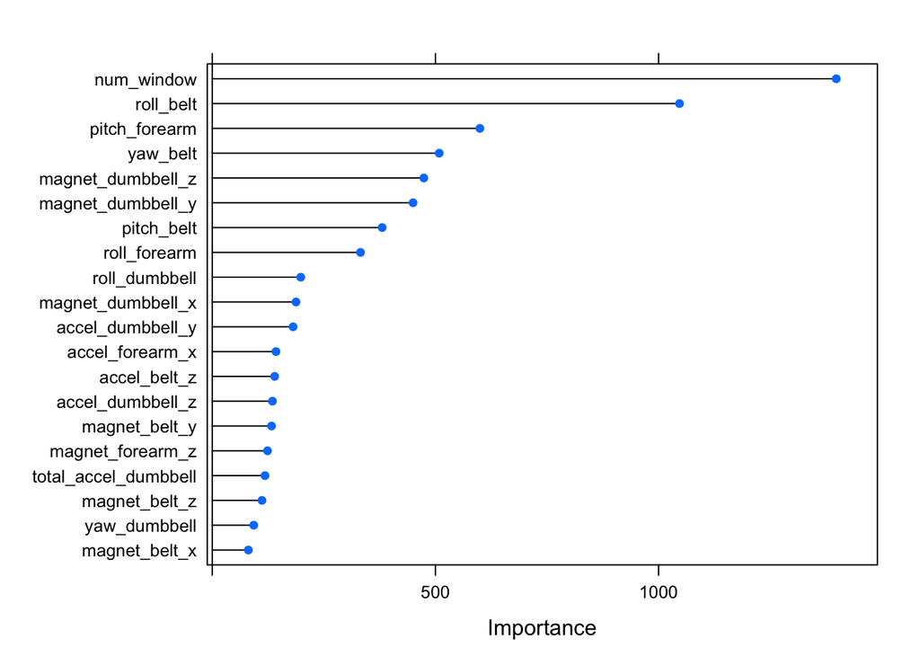

```r
varImport <- varImp(modFit1, scale = FALSE)
plot(varImport,20)
```

The model is used to predict the classe of the test data: Therefore the test data is loaded and all preprocessing steps are performed on the test data

```r
pml.testing <- read.csv("~/Documents/Data Science/Practical Machine Learning/pml-testing.csv")
test <- pml.testing
test.1 <- test[,-c(1:5)]
test.2 <- data.frame(lapply(test.1[,-155],
                            function(x) as.numeric(as.character(x))))
test.2$classe <- test.1$classe
test.3 <- test.2[,-nzv_d]
test.4 <- predict(preObj.1, newdata=test.3)
```

The preprocessed data is used for prediction:

```r
predict(modFit1, newdata=test.4)
```

```
##  [1] B A B A A E D B A A B C B A E E A B B B
## Levels: A B C D E
```

These predictions were used for the quiz.